# A Look at SAT/ACT Test Scores as They Relate to Demographics and Outcome Measures at Public Universities in the Various Regions of the US

D’Ette Wagar

2024-03-27

### This is an analysis of the relationships between the summary SAT and ACT test score data reported by universities and the regions, demographic information, and awards conferred by those universities. Data is sourced from: https://nces.ed.gov. It specifically targets the 2014-2015 adjusted cohort.

```r
install.packages("dplyr")
library(dplyr)
install.packages("tidyverse")
library(tidyverse)
install.packages("readr")
library(readr)
install.packages("tidyselect")
library(tidyselect)
install.packages("reshape2")
library(reshape2)
```

```r
install.packages("ggplot2")
library(ggplot2)
install.packages("readxl")
library(readxl)
install.packages("RColorBrewer")
library(RColorBrewer)
install.packages("corrplot")
library(corrplot)
# Load 2014 admissions data
admissions_df <- read.csv("adm2014_rv_data_stata.csv")

# Truncate admissions data to omit irrelevant info, including corresponding
# X columns that indicate how data was obtained
admissions_trunc_df <- admissions_df %>%
  select(UNITID, ADMCON7, starts_with("APPL"), starts_with("XAPPL"),
           starts_with("ADMS"), starts_with("XADMS"),  starts_with("ENRL"),
           starts_with("XENRL"), starts_with("SAT"), starts_with("XSAT"),
           starts_with("ACT"), starts_with("XACT"))

# From the truncated admissions data frame, create two admissions data frames,
# one with SAT data and one with ACT data. Each data frame is filtered separately
# so that all strictly reported SAT data can be examined independently of all
# strictly reported ACT data.

# Both data sets are filtered such that data in a column is identified as
# reported with a value of "R" in that column's corresponding X column, per the
# data dictionary
admissions_SAT_rptd_df <- admissions_trunc_df %>%
  select (UNITID, ADMCON7, starts_with("APPL"), starts_with("XAPPL"),
            starts_with("ADMS"), starts_with("XADMS"), starts_with("ENRL"),
            starts_with("XENRL"), starts_with("SAT"), starts_with("XSAT")) %>%
  filter(if_all(starts_with("X"), ~ . == "R"))

admissions_ACT_rptd_df <- admissions_trunc_df %>%
  select (UNITID, ADMCON7, starts_with("APPL"), starts_with("XAPPL"),
            starts_with("ADMS"), starts_with("XADMS"), starts_with("ENRL"),
            starts_with("XENRL"), starts_with("ACT"), starts_with("XACT")) %>%
  filter(if_all(starts_with("X"), ~ . == "R"))

# Load institution data
institution_df <- read.csv("hd2022_data_stata.csv")

# Filter institution data to include unit ID, name, region,
# control (public, private), historically black indicator, tribal indicator,
# locale code, active indicator, congressional district code.

# Data is limited to only public institutions (CONTROL == 1) that are not
# historically black (HBCU != 1) and not tribal (TRIBAL != 1).
institution_trunc_df <- institution_df %>%
  select(UNITID, INSTNM, OBEREG, CONTROL, HBCU, TRIBAL, LOCALE,
           CYACTIVE, CNGDSTCD) %>%
  filter(CONTROL == 1, HBCU != 1, TRIBAL != 1)


# Load enrollment data (multiple entries per unit ID)
enrollment_df <- read.csv("effy2022_data_stata.csv")

# Filter enrollment data to:
# 1) include data that was strictly reported,
#   as represented in each column that is named beginning with an "X" that
#   has a value of "R" (per the data dictionary),
# 2) include all enrolled students (EFFYALEV = 1 & EFFYLEV = 1), yielding
#   1 row per unit ID
enrollment_rptd_df <- filter(enrollment_df, if_all(starts_with("X"), ~ . == "R" )
                             & EFFYALEV == 1 & EFFYLEV == 1)

# Truncate enrollment data to omit irrelevant info
enrollment_rptd_trunc_df <- enrollment_rptd_df %>%
  select(UNITID, starts_with("EFY"))


# Join SAT admissions data and ACT admissions data to institutional data
inst_SAT_df <- merge(admissions_SAT_rptd_df, institution_trunc_df, by = "UNITID")
inst_ACT_df <- merge(admissions_ACT_rptd_df, institution_trunc_df, by = "UNITID")

# Join SAT admissions/instutional data and ACT admissions/instutional data to
# enrollment data
inst_enr_SAT_df <- merge(inst_SAT_df, enrollment_rptd_trunc_df, by = "UNITID")
inst_enr_ACT_df <- merge(inst_ACT_df, enrollment_rptd_trunc_df, by = "UNITID")

## Find mean SAT scores by region
mean_SAT_df <- inst_enr_SAT_df %>%
  group_by(OBEREG) %>%
  summarize(SAT_V_25 = mean(SATVR25), SAT_V_75= mean(SATVR75), SAT_M_25 =
             mean(SATMT25), SAT_M_75 = mean(SATMT75), SAT_W_25 =
             mean(SATWR25), SAT_W_75 = mean(SATWR75))

## Find mean ACT scores by region
mean_ACT_df <- inst_enr_ACT_df %>%
  group_by(OBEREG) %>%
  summarize(ACT_C_25 = mean(ACTCM25), ACT_C_75 = mean(ACTCM75),
            ACT_V_25 = mean(ACTEN25), ACT_V_75 = mean(ACTEN75),
            ACT_M_25 = mean(ACTMT25), ACT_M_75 = mean(ACTMT75),
            ACT_W_25 = mean(ACTWR25), ACT_W_75 = mean(ACTWR75))

# Reformat SAT data and display in bar graph
mean_SAT_df.long <- melt(mean_SAT_df,id.vars="OBEREG")
```

## SAT and ACT Scores by Region

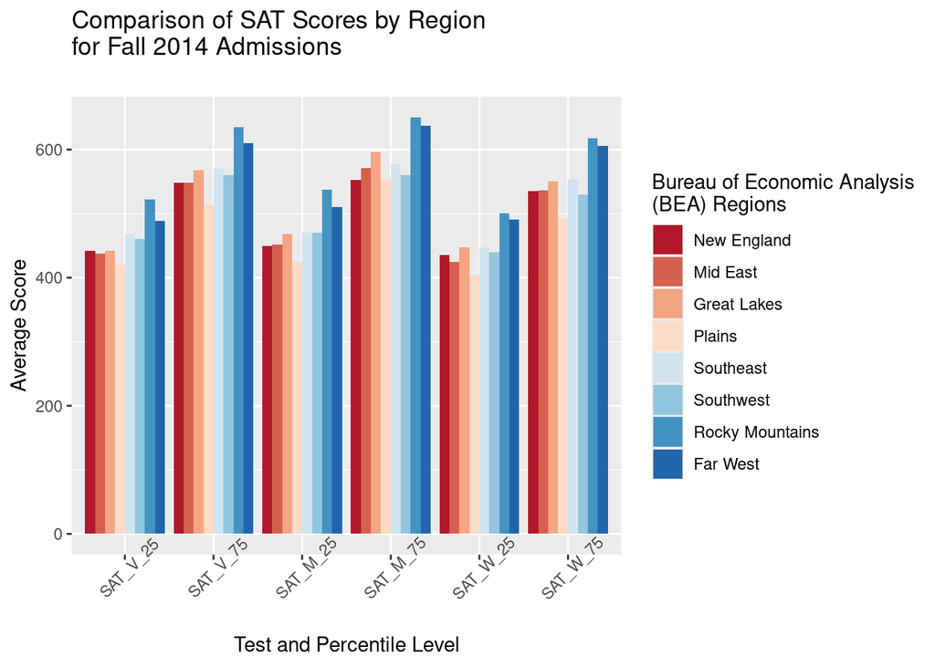

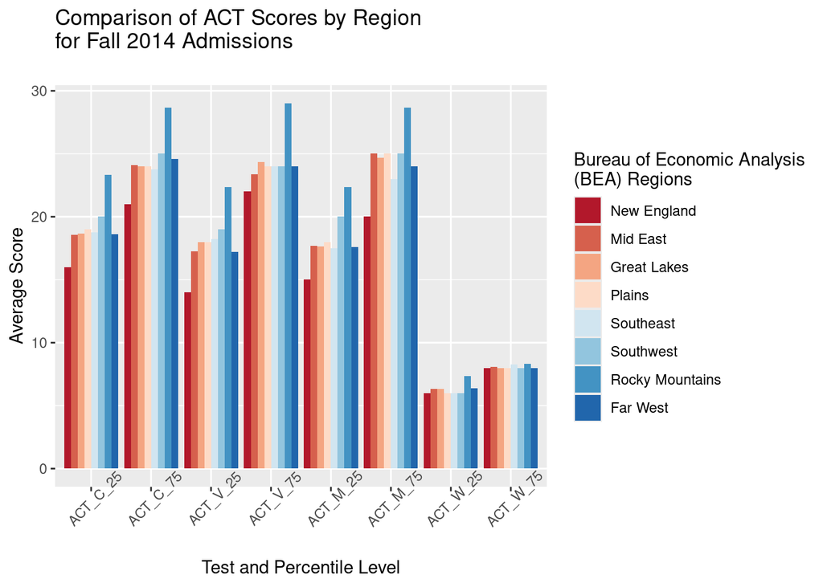

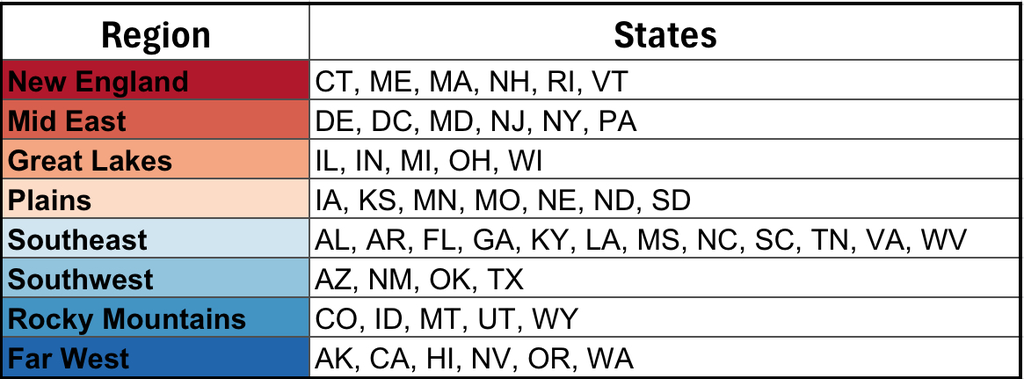

```r
# Reformat ACT data and display in bar graph
library(reshape2)
mean_ACT_df.long <- melt(mean_ACT_df,id.vars="OBEREG")
```

## Drill-Down Analysis of SAT and ACT Score Data

### We can see from the bar graphs above that regional performance is fairly consistent on both the SAT and ACT, both from test to test (verbal, math, etc.) and at the different percentiles of these tests.

[figure not shown]

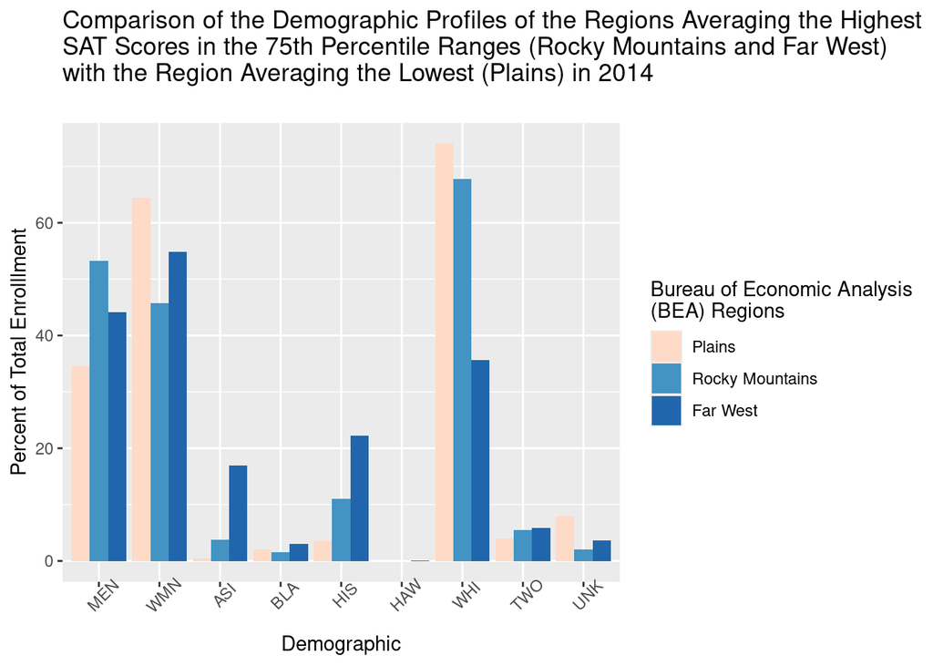

[figure not shown]

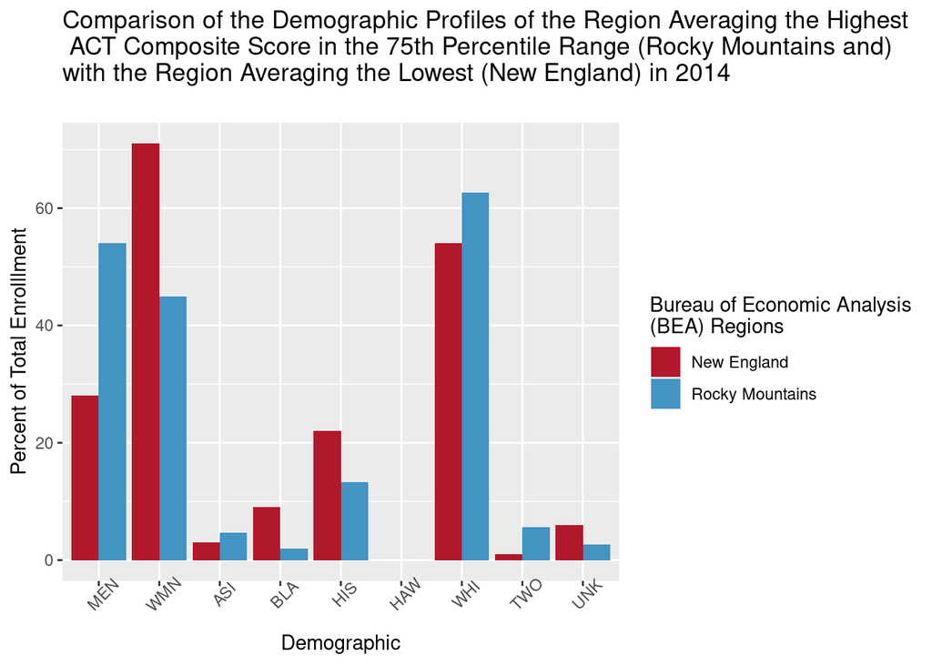

```r
# Let's take a look at how our high and low scoring regions break down by gender and race. For the SAT, we will focus on the Rocky Mountains and Far West regions on the high end and the Plains region on the low end. For the ACT, we will examine the Rocky Mountains and New England regions.

# Create rows of percentages

# Percent men enrolled
enrollment_rptd_trunc_df <- enrollment_rptd_trunc_df %>% mutate(PCT_MEN = as.integer(EFYTOTLM/EFYTOTLT * 100))

# Percent women enrolled
enrollment_rptd_trunc_df <- enrollment_rptd_trunc_df %>% mutate(PCT_WMN = as.integer(EFYTOTLW/EFYTOTLT * 100))

# Percent Asian
enrollment_rptd_trunc_df <- enrollment_rptd_trunc_df %>% mutate(PCT_ASI = as.integer(EFYASIAT/EFYTOTLT * 100))

# Percent Black
enrollment_rptd_trunc_df <- enrollment_rptd_trunc_df %>% mutate(PCT_BLA = as.integer(EFYBKAAT/EFYTOTLT * 100))

# Percent Hispanic or Latinx
enrollment_rptd_trunc_df <- enrollment_rptd_trunc_df %>% mutate(PCT_HIS = as.integer(EFYHISPT/EFYTOTLT * 100))

# Percent N. Hawaiian or O. Pacific Islander
enrollment_rptd_trunc_df <- enrollment_rptd_trunc_df %>% mutate(PCT_HAW = as.integer(EFYNHPIT/EFYTOTLT * 100))

# Percent White
enrollment_rptd_trunc_df <- enrollment_rptd_trunc_df %>% mutate(PCT_WHI = as.integer(EFYWHITT/EFYTOTLT * 100))

# Percent 2 or more Races
enrollment_rptd_trunc_df <- enrollment_rptd_trunc_df %>% mutate(PCT_2OR = as.integer(EFY2MORT/EFYTOTLT * 100))

# Percent Race Unknown
enrollment_rptd_trunc_df <- enrollment_rptd_trunc_df %>% mutate(PCT_UNK = as.integer(EFYUNKNT/EFYTOTLT * 100))

# **Gender percentages may not add up to 100, as some genders may bave been reported as "unknown" or "other".

# Join SAT admissions/instutional data and ACT admissions/instutional data to
# UPDATED enrollment data
upd_enr_SAT_df <- merge(inst_SAT_df, enrollment_rptd_trunc_df, by = "UNITID")
upd_enr_ACT_df <- merge(inst_ACT_df, enrollment_rptd_trunc_df, by = "UNITID")

## For SAT data, find the enrollment percentages by gender and race, by region and filter to view only the Rocky Mountains, Far West, and Plains regions
mean_gen_race_SAT_df <- upd_enr_SAT_df %>%
  group_by(OBEREG) %>%
  summarize(MEN = mean(PCT_MEN), WMN = mean(PCT_WMN), ASI = mean(PCT_ASI),
            BLA = mean(PCT_BLA), HIS = mean(PCT_HIS), HAW = mean(PCT_HAW),
            WHI = mean(PCT_WHI), TWO = mean(PCT_2OR), UNK = mean(PCT_UNK)) %>%
  filter(OBEREG %in% c(4,7,8))

## For ACT data, find the enrollment percentages by gender and race, by region and filter to view only the New England and Rocky Mountains regions
mean_gen_race_ACT_df <- upd_enr_ACT_df %>%
  group_by(OBEREG) %>%
  summarize(MEN = mean(PCT_MEN), WMN = mean(PCT_WMN), ASI = mean(PCT_ASI),
            BLA = mean(PCT_BLA), HIS = mean(PCT_HIS), HAW = mean(PCT_HAW),
            WHI = mean(PCT_WHI), TWO = mean(PCT_2OR), UNK = mean(PCT_UNK)) %>%
  filter(OBEREG %in% c(1,7))

# Reformat data and display in bar graph
mean_gen_race_SAT_df.long <- melt(mean_gen_race_SAT_df,id.vars="OBEREG")

mean_gen_race_ACT_df.long <- melt(mean_gen_race_ACT_df,id.vars="OBEREG")
```

### Interestingly, lower math scores seem to be related to a greater percentage of women enrolled. Let’s examine that more closely by looking at the statistical correlation coefficients between percent women enrolled and scores.

```r
# Create SAT data set containing just the values of unit ID, percent women enrolled, and SAT scores. Then create the correlation matrix.
gender_SAT_df <- inst_enr_SAT_df %>%
  mutate(PCT_WMN = as.integer(EFYTOTLW/EFYTOTLT * 100)) %>%
  select(UNITID, PCT_WMN, SATVR25, SATVR75, SATMT25,
         SATMT75, SATWR25, SATWR75)

colnames(gender_SAT_df) <- c('UNITID', 'PCT_WMN', 'SAT_V_25', 'SAT_V_75',
                             'SAT_M_25', 'SAT_M_75', 'SAT_W_25', 'SAT_W_75')
```

```
##          UNITID PCT_WMN SAT_V_25 SAT_V_75 SAT_M_25 SAT_M_75 SAT_W_25 SAT_W_75
## UNITID     1.00   -0.14    -0.36    -0.34    -0.40    -0.39    -0.38    -0.36
## PCT_WMN   -0.14    1.00    -0.18    -0.22    -0.25    -0.29    -0.15    -0.22
## SAT_V_25  -0.36   -0.18     1.00     0.94     0.94     0.87     0.96     0.92
## SAT_V_75  -0.34   -0.22     0.94     1.00     0.91     0.91     0.94     0.96
## SAT_M_25  -0.40   -0.25     0.94     0.91     1.00     0.95     0.96     0.91
## SAT_M_75  -0.39   -0.29     0.87     0.91     0.95     1.00     0.92     0.92
## SAT_W_25  -0.38   -0.15     0.96     0.94     0.96     0.92     1.00     0.95
## SAT_W_75  -0.36   -0.22     0.92     0.96     0.91     0.92     0.95     1.00
```

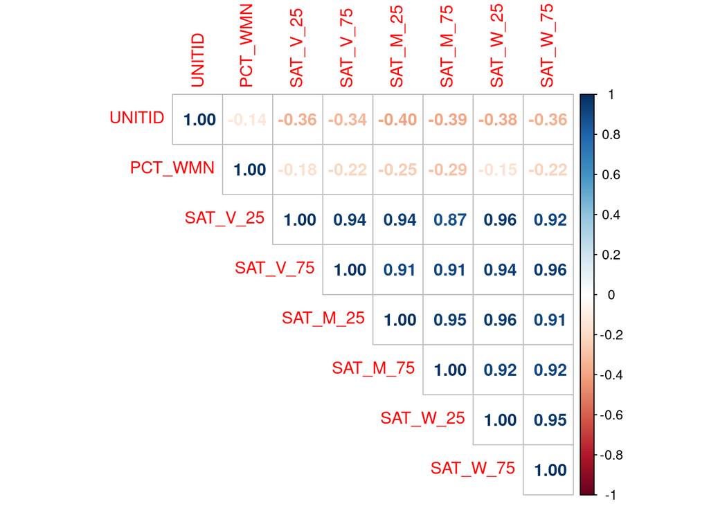

### The 75th percentile SAT math scores and the the percent women variables have a correlation coefficient of -.29, indicating that they *might* be correlated. To investigate further, we conduct a null test of the hypothesis, supposing the opposite: that there is **no** connection between the two. If the resulting p value is less than .05, meaning that there is less than a 5% chance that the 2 variables are correlated, then you can reject the hypothesis that there is no connection between the two.

```r
# Null test of the hypothesis for the percent women variable and the SAT math
# 75th percentile score variable
cor.test(gender_SAT_df$PCT_WMN, gender_SAT_df$SAT_M_75)
```

```
##
##  Pearson's product-moment correlation
##
## data:  gender_SAT_df$PCT_WMN and gender_SAT_df$SAT_M_75
## t = -2.6126, df = 72, p-value = 0.01093
## alternative hypothesis: true correlation is not equal to 0
## 95 percent confidence interval:
##  -0.48983168 -0.07051179
## sample estimates:
##        cor
## -0.2942693
```

### The p value is low enough for us to reject the null hypothesis that there is no relationship between the score and the percent of wome who took the test. Therefore, there **is** a relationship between the score and the percent of women who took the test.

### Let us see if that relationship holds for the 25th percentile test as well.

```r
# Null test of the hypothesis for the percent women variable and the SAT math
# 25th percentile score variable
cor.test(gender_SAT_df$PCT_WMN, gender_SAT_df$SAT_M_25)
```

```
##
##  Pearson's product-moment correlation
##
## data:  gender_SAT_df$PCT_WMN and gender_SAT_df$SAT_M_25
## t = -2.2088, df = 72, p-value = 0.03037
## alternative hypothesis: true correlation is not equal to 0
## 95 percent confidence interval:
##  -0.45426730 -0.02484911
## sample estimates:
##        cor
## -0.2519175
```

### Indeed, the p value is in the significant range for this test as well, so we come to the same conclusion for this test and percentile marker.

### To further verify these results, we examine the p-values of the verbal SAT tests, where we do not expect to see the same results:

```r
# Null test of the hypothesis for the percent women variable and the SAT verbal
# 75th percentile score variable
cor.test(gender_SAT_df$PCT_WMN, gender_SAT_df$SAT_V_75)
```

```
##
##  Pearson's product-moment correlation
##
## data:  gender_SAT_df$PCT_WMN and gender_SAT_df$SAT_V_75
## t = -1.8858, df = 72, p-value = 0.06336
## alternative hypothesis: true correlation is not equal to 0
## 95 percent confidence interval:
##  -0.42440641  0.01215495
## sample estimates:
##        cor
## -0.2169463
```

```r
# Null test of the hypothesis for the percent women variable and the SAT verbal
# 25th percentile score variable
cor.test(gender_SAT_df$PCT_WMN, gender_SAT_df$SAT_V_25)
```

```
##
##  Pearson's product-moment correlation
##
## data:  gender_SAT_df$PCT_WMN and gender_SAT_df$SAT_V_25
## t = -1.543, df = 72, p-value = 0.1272
## alternative hypothesis: true correlation is not equal to 0
## 95 percent confidence interval:
##  -0.3914056  0.0517049
## sample estimates:
##        cor
## -0.1789075
```

### Not surprisingly, we cannot reject the hypothesis that there is no relationship between the percent of women who took the verbal test, at either score level, since the p value of each test is greater than .05.

```r
# Create data set containing just the values of unit ID, percent women enrolled, and SAT scores. Then create the correlation matrix.
gender_ACT_df <- inst_enr_ACT_df %>%
  mutate(PCT_WMN = as.integer(EFYTOTLW/EFYTOTLT * 100)) %>%
  select(UNITID, PCT_WMN, ACTCM25, ACTCM75, ACTEN25,
         ACTEN75, ACTMT25, ACTMT75, ACTWR25, ACTWR75)

colnames(gender_ACT_df) <- c('UNITID', 'PCT_WMN', 'ACT_C_25', 'ACT_C_75',
                             'ACT_V_25', 'ACT_V_75', 'ACT_M_25', 'ACT_M_75',
                             'ACT_W_25', 'ACT_W_75')
```

```
##          UNITID PCT_WMN ACT_C_25 ACT_C_75 ACT_V_25 ACT_V_75 ACT_M_25 ACT_M_75
## UNITID     1.00   -0.07    -0.10     0.05    -0.04    -0.11    -0.24    -0.11
## PCT_WMN   -0.07    1.00    -0.24    -0.32    -0.22    -0.18    -0.27    -0.51
## ACT_C_25  -0.10   -0.24     1.00     0.83     0.90     0.82     0.88     0.75
## ACT_C_75   0.05   -0.32     0.83     1.00     0.87     0.93     0.82     0.78
## ACT_V_25  -0.04   -0.22     0.90     0.87     1.00     0.88     0.79     0.72
## ACT_V_75  -0.11   -0.18     0.82     0.93     0.88     1.00     0.83     0.71
## ACT_M_25  -0.24   -0.27     0.88     0.82     0.79     0.83     1.00     0.75
## ACT_M_75  -0.11   -0.51     0.75     0.78     0.72     0.71     0.75     1.00
## ACT_W_25  -0.37   -0.21     0.47     0.39     0.40     0.46     0.61     0.29
## ACT_W_75  -0.23   -0.21     0.38     0.32     0.32     0.33     0.53     0.15
##          ACT_W_25 ACT_W_75
## UNITID      -0.37    -0.23
## PCT_WMN     -0.21    -0.21
## ACT_C_25     0.47     0.38
## ACT_C_75     0.39     0.32
## ACT_V_25     0.40     0.32
## ACT_V_75     0.46     0.33
## ACT_M_25     0.61     0.53
## ACT_M_75     0.29     0.15
## ACT_W_25     1.00     0.59
## ACT_W_75     0.59     1.00
```

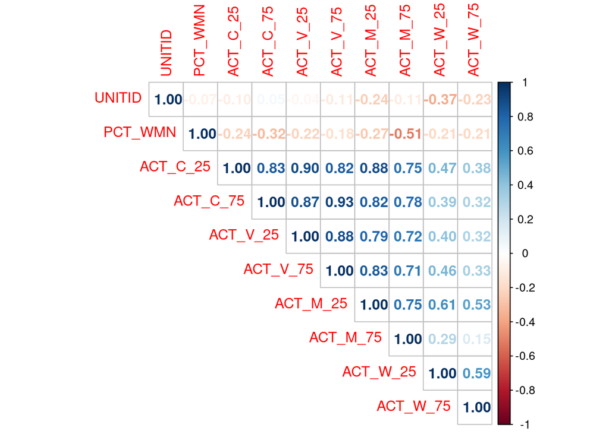

```r
# Null test of the hypothesis for the percent women variable and the ACT math
# 75th percentile score variable
cor.test(gender_ACT_df$PCT_WMN, gender_ACT_df$ACT_M_75)
```

```
##
##  Pearson's product-moment correlation
##
## data:  gender_ACT_df$PCT_WMN and gender_ACT_df$ACT_M_75
## t = -3.6748, df = 38, p-value = 0.0007314
## alternative hypothesis: true correlation is not equal to 0
## 95 percent confidence interval:
##  -0.7102669 -0.2386010
## sample estimates:
##        cor
## -0.5120514
```

```r
# Null test of the hypothesis for the percent women variable and the ACT math
# 25th percentile score variable
cor.test(gender_ACT_df$PCT_WMN, gender_ACT_df$ACT_M_25)
```

```
##
##  Pearson's product-moment correlation
##
## data:  gender_ACT_df$PCT_WMN and gender_ACT_df$ACT_M_25
## t = -1.698, df = 38, p-value = 0.09767
## alternative hypothesis: true correlation is not equal to 0
## 95 percent confidence interval:
##  -0.53298577  0.05008381
## sample estimates:
##        cor
## -0.2655688
```

## SAT and ACT Scores, in Comparison to Percent of Awards (Certificates or Degrees) Conferred at 4, 6, and 8 Years, by Region

### Finally, let’s examine overall region’s average SAT and ACT scores in relation to their average percent awards conferred at 4, 6, and 8 years. Awards include certificates or degrees.

```r
# Load outcome measure data
outcome_df <- read.csv("om2022_data_stata.csv")

# Truncate outcome data to include only percent of adjusted cohort to receive
# awards at 4, 6, and 8 years, filtering to include only data reported by each
# institution and data for all entering students in the 2014-2015 cohort
#(OMCHRT=50). (Setting OMCHRT=50 limits output to one row per UNITID.)
outcome_trunc_df <- outcome_df %>%
  select(UNITID, OMCHRT, OMAWDP4, XOMAWDP4, OMAWDP6, XOMAWDP6, OMAWDP8,
         XOMAWDP8) %>%
   filter(if_all(starts_with("X"), ~ . == "R"), OMCHRT==50)

# Join SAT institutional/enrollment data to outcome data
outcome_SAT_df <- merge(inst_enr_SAT_df, outcome_trunc_df, by = "UNITID")

# Find mean SAT scores and mean percentage of awards conferred per region
mean_outcome_df <- outcome_SAT_df %>%
  group_by(OBEREG) %>%
  summarize(SAT_V_25TH = mean(SATVR25), SAT_V_75TH= mean(SATVR75),
            SAT_M_25TH = mean(SATMT25), SAT_M_75TH = mean(SATMT75),
            SAT_W_25TH = mean(SATWR25), SAT_W_75TH = mean(SATWR75),
            PCT_AWD_4Y = mean(OMAWDP4), PCT_AWD_6Y = mean(OMAWDP6),
            PCT_AWD_8Y = mean(OMAWDP8))

# Separate out just the SAT scores
mean_outcome_SAT_df <- mean_outcome_df %>%
  select(OBEREG, SAT_V_25TH, SAT_V_75TH, SAT_M_25TH, SAT_M_75TH, SAT_W_25TH,
         SAT_W_75TH)

# Reformat mean SAT data and display in bar graph
mean_outcome_SAT_df.long <- melt(mean_outcome_SAT_df,id.vars="OBEREG")

# Separate out just the mean percent awards
mean_outcome_awd_df <- mean_outcome_df %>%
  select(OBEREG, PCT_AWD_4Y, PCT_AWD_6Y, PCT_AWD_8Y)

# Reformat mean percent award data and display in bar graph
mean_outcome_awd_df.long <- melt(mean_outcome_awd_df,id.vars="OBEREG")
```

### SAT Scores, along with Awards Conferred, by Region

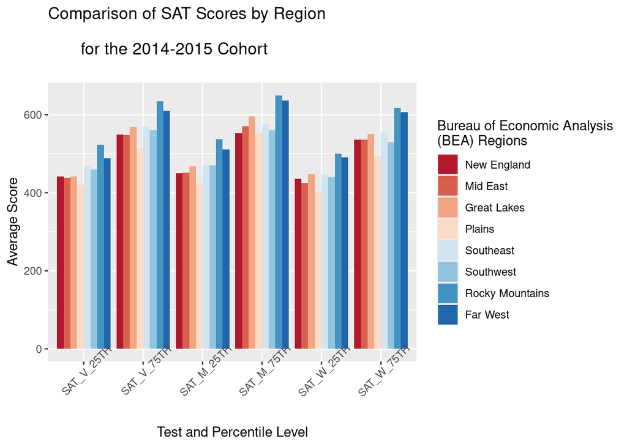

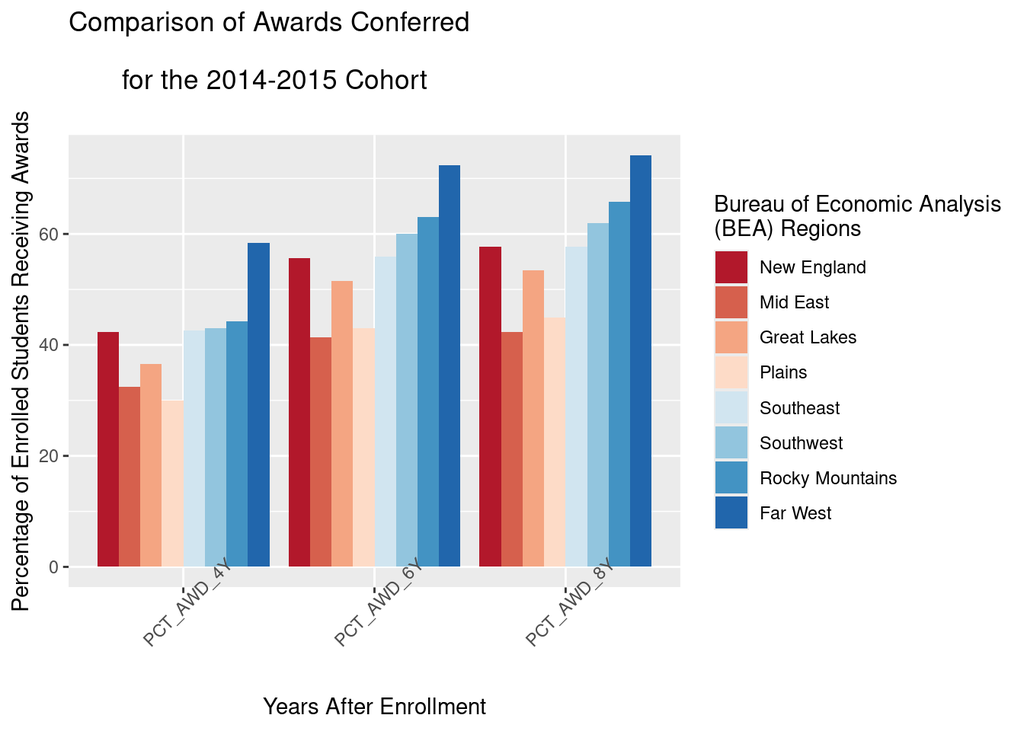

### There appear to be similarities between the test data and the outcome measure data; the regions with higher test scores tend to have larger percentages of awards conferred and vice versa. Let’s create a correlation matrix to explore those relationships further.

```
##            UNITID SAT_V_25 SAT_V_75 SAT_M_25 SAT_M_75 SAT_W_25 SAT_W_75
## UNITID       1.00    -0.36    -0.34    -0.40    -0.39    -0.38    -0.36
## SAT_V_25    -0.36     1.00     0.94     0.94     0.87     0.96     0.92
## SAT_V_75    -0.34     0.94     1.00     0.91     0.91     0.94     0.96
## SAT_M_25    -0.40     0.94     0.91     1.00     0.95     0.96     0.91
## SAT_M_75    -0.39     0.87     0.91     0.95     1.00     0.92     0.92
## SAT_W_25    -0.38     0.96     0.94     0.96     0.92     1.00     0.95
## SAT_W_75    -0.36     0.92     0.96     0.91     0.92     0.95     1.00
## PCT_AWD_4Y  -0.36     0.78     0.74     0.79     0.73     0.83     0.76
## PCT_AWD_6Y  -0.34     0.78     0.74     0.79     0.73     0.83     0.75
## PCT_AWD_8Y  -0.33     0.78     0.74     0.79     0.72     0.82     0.75
##            PCT_AWD_4Y PCT_AWD_6Y PCT_AWD_8Y
## UNITID          -0.36      -0.34      -0.33
## SAT_V_25         0.78       0.78       0.78
## SAT_V_75         0.74       0.74       0.74
## SAT_M_25         0.79       0.79       0.79
## SAT_M_75         0.73       0.73       0.72
## SAT_W_25         0.83       0.83       0.82
## SAT_W_75         0.76       0.75       0.75
## PCT_AWD_4Y       1.00       0.97       0.97
## PCT_AWD_6Y       0.97       1.00       1.00
## PCT_AWD_8Y       0.97       1.00       1.00
```

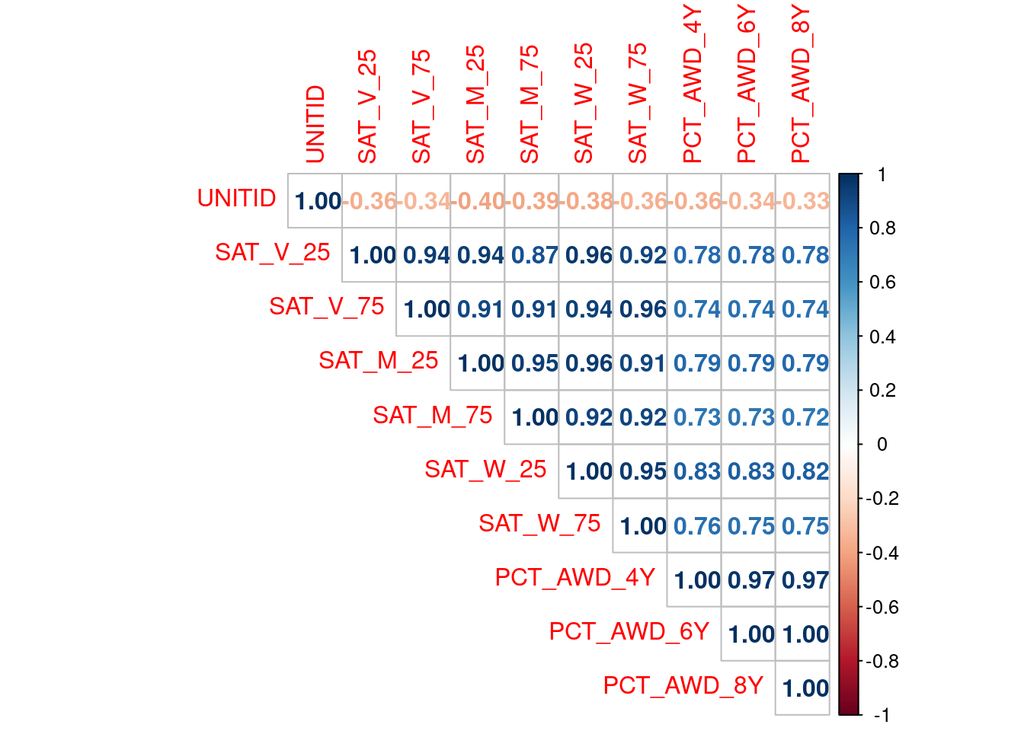

### The correlation matrix indicates that there could be correlations among each of the test variables and each of the award variables. The following null hypothesis tests confirm that indeed there is a correlation in every case.

```
##
##  Pearson's product-moment correlation
##
## data:  num_outcome_SAT_df$PCT_AWD_4Y and num_outcome_SAT_df$SAT_V_25
## t = 10.428, df = 72, p-value = 4.876e-16
## alternative hypothesis: true correlation is not equal to 0
## 95 percent confidence interval:
##  0.6650258 0.8529773
## sample estimates:
##       cor
## 0.7756575
```

```
##
##  Pearson's product-moment correlation
##
## data:  num_outcome_SAT_df$PCT_AWD_4Y and num_outcome_SAT_df$SAT_V_75
## t = 9.3867, df = 72, p-value = 3.997e-14
## alternative hypothesis: true correlation is not equal to 0
## 95 percent confidence interval:
##  0.618102 0.829689
## sample estimates:
##       cor
## 0.7418282
```

```
##
##  Pearson's product-moment correlation
##
## data:  num_outcome_SAT_df$PCT_AWD_4Y and num_outcome_SAT_df$SAT_M_25
## t = 10.875, df = 72, p-value < 2.2e-16
## alternative hypothesis: true correlation is not equal to 0
## 95 percent confidence interval:
##  0.6829318 0.8616711
## sample estimates:
##       cor
## 0.7884013
```

```
##
##  Pearson's product-moment correlation
##
## data:  num_outcome_SAT_df$PCT_AWD_4Y and num_outcome_SAT_df$SAT_M_75
## t = 9.0434, df = 72, p-value = 1.734e-13
## alternative hypothesis: true correlation is not equal to 0
## 95 percent confidence interval:
##  0.6008798 0.8209528
## sample estimates:
##      cor
## 0.729252
```

```
##
##  Pearson's product-moment correlation
##
## data:  num_outcome_SAT_df$PCT_AWD_4Y and num_outcome_SAT_df$SAT_W_25
## t = 12.599, df = 72, p-value < 2.2e-16
## alternative hypothesis: true correlation is not equal to 0
## 95 percent confidence interval:
##  0.7414646 0.8893764
## sample estimates:
##      cor
## 0.829437
```

```
##
##  Pearson's product-moment correlation
##
## data:  num_outcome_SAT_df$PCT_AWD_4Y and num_outcome_SAT_df$SAT_W_75
## t = 9.8141, df = 72, p-value = 6.487e-15
## alternative hypothesis: true correlation is not equal to 0
## 95 percent confidence interval:
##  0.6382930 0.8398009
## sample estimates:
##       cor
## 0.7564624
```

```
##
##  Pearson's product-moment correlation
##
## data:  num_outcome_SAT_df$PCT_AWD_6Y and num_outcome_SAT_df$SAT_V_25
## t = 10.587, df = 72, p-value = 2.506e-16
## alternative hypothesis: true correlation is not equal to 0
## 95 percent confidence interval:
##  0.6715433 0.8561538
## sample estimates:
##       cor
## 0.7803065
```

```
##
##  Pearson's product-moment correlation
##
## data:  num_outcome_SAT_df$PCT_AWD_6Y and num_outcome_SAT_df$SAT_V_75
## t = 9.46, df = 72, p-value = 2.924e-14
## alternative hypothesis: true correlation is not equal to 0
## 95 percent confidence interval:
##  0.6216613 0.8314817
## sample estimates:
##       cor
## 0.7444165
```

```
##
##  Pearson's product-moment correlation
##
## data:  num_outcome_SAT_df$PCT_AWD_6Y and num_outcome_SAT_df$SAT_M_25
## t = 10.989, df = 72, p-value < 2.2e-16
## alternative hypothesis: true correlation is not equal to 0
## 95 percent confidence interval:
##  0.6873220 0.8637867
## sample estimates:
##      cor
## 0.791512
```

```
##
##  Pearson's product-moment correlation
##
## data:  num_outcome_SAT_df$PCT_AWD_6Y and num_outcome_SAT_df$SAT_M_75
## t = 8.9821, df = 72, p-value = 2.255e-13
## alternative hypothesis: true correlation is not equal to 0
## 95 percent confidence interval:
##  0.5977078 0.8193324
## sample estimates:
##       cor
## 0.7269262
```

```
##
##  Pearson's product-moment correlation
##
## data:  num_outcome_SAT_df$PCT_AWD_6Y and num_outcome_SAT_df$SAT_W_25
## t = 12.52, df = 72, p-value < 2.2e-16
## alternative hypothesis: true correlation is not equal to 0
## 95 percent confidence interval:
##  0.7391128 0.8882838
## sample estimates:
##       cor
## 0.8278064
```

```
##
##  Pearson's product-moment correlation
##
## data:  num_outcome_SAT_df$PCT_AWD_6Y and num_outcome_SAT_df$SAT_W_75
## t = 9.572, df = 72, p-value = 1.814e-14
## alternative hypothesis: true correlation is not equal to 0
## 95 percent confidence interval:
##  0.6270230 0.8341739
## sample estimates:
##       cor
## 0.7483086
```

```
##
##  Pearson's product-moment correlation
##
## data:  num_outcome_SAT_df$PCT_AWD_8Y and num_outcome_SAT_df$SAT_V_25
## t = 10.5, df = 72, p-value = 3.612e-16
## alternative hypothesis: true correlation is not equal to 0
## 95 percent confidence interval:
##  0.6679812 0.8544195
## sample estimates:
##       cor
## 0.7777671
```

```
##
##  Pearson's product-moment correlation
##
## data:  num_outcome_SAT_df$PCT_AWD_8Y and num_outcome_SAT_df$SAT_V_75
## t = 9.4719, df = 72, p-value = 2.779e-14
## alternative hypothesis: true correlation is not equal to 0
## 95 percent confidence interval:
##  0.6222358 0.8317707
## sample estimates:
##      cor
## 0.744834
```

```
##
##  Pearson's product-moment correlation
##
## data:  num_outcome_SAT_df$PCT_AWD_8Y and num_outcome_SAT_df$SAT_M_25
## t = 10.817, df = 72, p-value < 2.2e-16
## alternative hypothesis: true correlation is not equal to 0
## 95 percent confidence interval:
##  0.6806916 0.8605891
## sample estimates:
##       cor
## 0.7868119
```

```
##
##  Pearson's product-moment correlation
##
## data:  num_outcome_SAT_df$PCT_AWD_8Y and num_outcome_SAT_df$SAT_M_75
## t = 8.888, df = 72, p-value = 3.376e-13
## alternative hypothesis: true correlation is not equal to 0
## 95 percent confidence interval:
##  0.5927750 0.8168055
## sample estimates:
##       cor
## 0.7233035
```

```
##
##  Pearson's product-moment correlation
##
## data:  num_outcome_SAT_df$PCT_AWD_8Y and num_outcome_SAT_df$SAT_W_25
## t = 12.362, df = 72, p-value < 2.2e-16
## alternative hypothesis: true correlation is not equal to 0
## 95 percent confidence interval:
##  0.7342940 0.8860398
## sample estimates:
##       cor
## 0.8244605
```

```
##
##  Pearson's product-moment correlation
##
## data:  num_outcome_SAT_df$PCT_AWD_8Y and num_outcome_SAT_df$SAT_W_75
## t = 9.4998, df = 72, p-value = 2.467e-14
## alternative hypothesis: true correlation is not equal to 0
## 95 percent confidence interval:
##  0.6235779 0.8324452
## sample estimates:
##       cor
## 0.7458088
```

```r
# Join ACT institutional/enrollment data to outcome data
outcome_ACT_df <- merge(inst_enr_ACT_df, outcome_trunc_df, by = "UNITID")

# Find mean ACT scores and mean percentage of awards conferred per region
mean_outcome2_df <- outcome_ACT_df %>%
  group_by(OBEREG) %>%
summarize(ACT_C_25 = mean(ACTCM25), ACT_C_75 = mean(ACTCM75),
          ACT_V_25 = mean(ACTEN25), ACT_V_75 = mean(ACTEN75),
          ACT_M_25 = mean(ACTMT25), ACT_M_75 = mean(ACTMT75),
          ACT_W_25 = mean(ACTWR25), ACT_W_75 = mean(ACTWR75),
          PCT_AWD_4Y = mean(OMAWDP4), PCT_AWD_6Y = mean(OMAWDP6),
          PCT_AWD_8Y = mean(OMAWDP8))

# Separate out just the ACT scores
mean_outcome_ACT_df <- mean_outcome2_df %>%
select(OBEREG, ACT_C_25, ACT_C_75, ACT_V_25, ACT_V_75, ACT_M_25,
       ACT_M_75, ACT_W_25, ACT_W_75)

# Reformat mean ACT data and display in bar graph
mean_outcome_ACT_df.long <- melt(mean_outcome_ACT_df,id.vars="OBEREG")

# Separate out just the mean percent awards
mean_outcome_awd2_df <- mean_outcome2_df %>%
  select(OBEREG, PCT_AWD_4Y, PCT_AWD_6Y, PCT_AWD_8Y)

# Reformat mean percent award data and display in bar graph
mean_outcome_awd2_df.long <- melt(mean_outcome_awd2_df,id.vars="OBEREG")
```

### ACT Scores, along with Awards Conferred, by Region

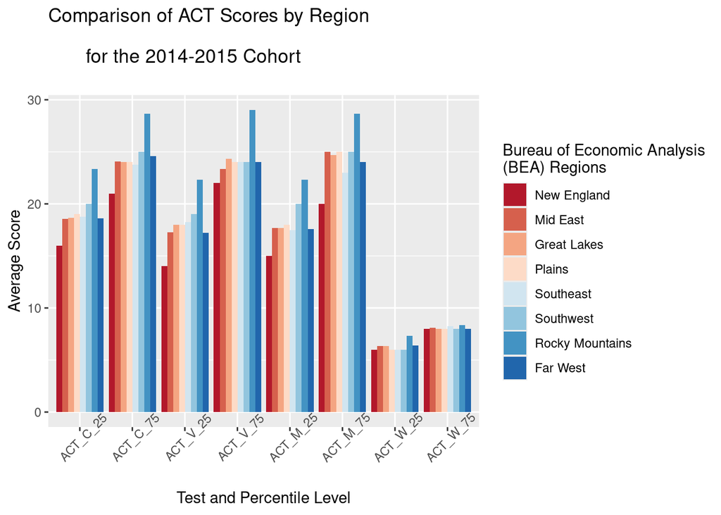

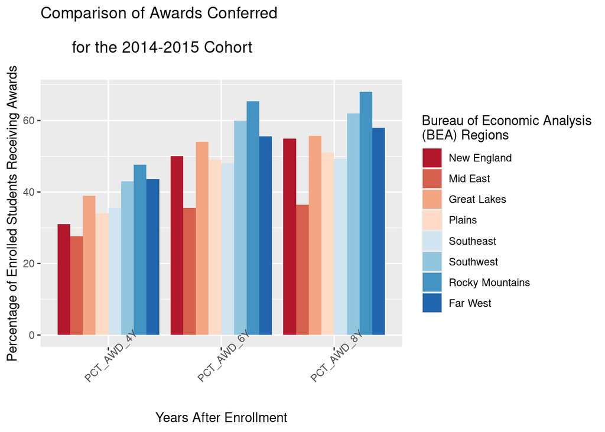

### Once again, there appear to be similarities between the test data and the outcome measure data. We create a correlation matrix to take a closer look.

```
##            UNITID ACT_C_25 ACT_C_75 ACT_V_25 ACT_V_75 ACT_M_25 ACT_M_75
## UNITID       1.00    -0.10     0.05    -0.04    -0.11    -0.24    -0.11
## ACT_C_25    -0.10     1.00     0.83     0.90     0.82     0.88     0.75
## ACT_C_75     0.05     0.83     1.00     0.87     0.93     0.82     0.78
## ACT_V_25    -0.04     0.90     0.87     1.00     0.88     0.79     0.72
## ACT_V_75    -0.11     0.82     0.93     0.88     1.00     0.83     0.71
## ACT_M_25    -0.24     0.88     0.82     0.79     0.83     1.00     0.75
## ACT_M_75    -0.11     0.75     0.78     0.72     0.71     0.75     1.00
## ACT_W_25    -0.37     0.47     0.39     0.40     0.46     0.61     0.29
## ACT_W_75    -0.23     0.38     0.32     0.32     0.33     0.53     0.15
## PCT_AWD_4Y  -0.18     0.62     0.55     0.52     0.61     0.65     0.43
## PCT_AWD_6Y  -0.21     0.60     0.56     0.55     0.64     0.64     0.41
## PCT_AWD_8Y  -0.19     0.59     0.56     0.55     0.65     0.63     0.39
##            ACT_W_25 ACT_W_75 PCT_AWD_4Y PCT_AWD_6Y PCT_AWD_8Y
## UNITID        -0.37    -0.23      -0.18      -0.21      -0.19
## ACT_C_25       0.47     0.38       0.62       0.60       0.59
## ACT_C_75       0.39     0.32       0.55       0.56       0.56
## ACT_V_25       0.40     0.32       0.52       0.55       0.55
## ACT_V_75       0.46     0.33       0.61       0.64       0.65
## ACT_M_25       0.61     0.53       0.65       0.64       0.63
## ACT_M_75       0.29     0.15       0.43       0.41       0.39
## ACT_W_25       1.00     0.59       0.46       0.44       0.42
## ACT_W_75       0.59     1.00       0.40       0.35       0.34
## PCT_AWD_4Y     0.46     0.40       1.00       0.97       0.96
## PCT_AWD_6Y     0.44     0.35       0.97       1.00       1.00
## PCT_AWD_8Y     0.42     0.34       0.96       1.00       1.00
```

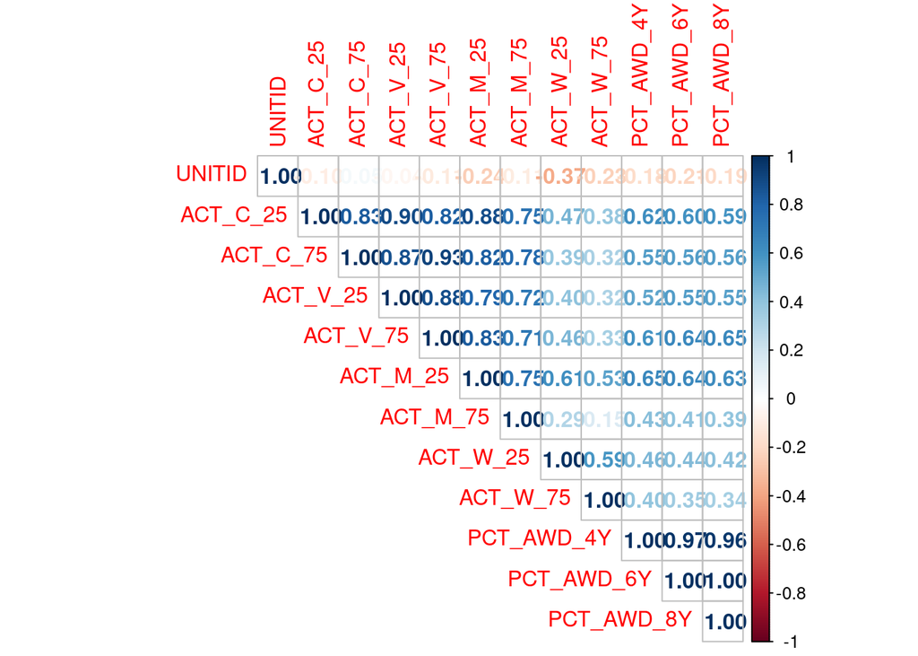

### As with the SAT tests, the correlation matrix indicates that there could be correlations among each of the test variables and each of the award variables. Also as with the SAT tests, the following null hypothesis tests confirm that indeed there is a correlation in every case. Interestingly, though, the correlation coefficients for the different score percentiles within the ACT are not as consistent as they are within the SAT. Although outside the scope of this analysis, an exploration into the reasons for these differences might be worthwhile.

```
##
##  Pearson's product-moment correlation
##
## data:  num_outcome_ACT_df$PCT_AWD_4Y and num_outcome_ACT_df$ACT_C_25
## t = 4.8464, df = 38, p-value = 2.143e-05
## alternative hypothesis: true correlation is not equal to 0
## 95 percent confidence interval:
##  0.3796302 0.7794862
## sample estimates:
##     cor
## 0.61805
```

```
##
##  Pearson's product-moment correlation
##
## data:  num_outcome_ACT_df$PCT_AWD_4Y and num_outcome_ACT_df$ACT_C_75
## t = 4.0856, df = 38, p-value = 0.0002189
## alternative hypothesis: true correlation is not equal to 0
## 95 percent confidence interval:
##  0.2910204 0.7371062
## sample estimates:
##       cor
## 0.5524474
```

```
##
##  Pearson's product-moment correlation
##
## data:  num_outcome_ACT_df$PCT_AWD_4Y and num_outcome_ACT_df$ACT_V_25
## t = 3.795, df = 38, p-value = 0.0005161
## alternative hypothesis: true correlation is not equal to 0
## 95 percent confidence interval:
##  0.2542662 0.7184339
## sample estimates:
##       cor
## 0.5242515
```

```
##
##  Pearson's product-moment correlation
##
## data:  num_outcome_ACT_df$PCT_AWD_4Y and num_outcome_ACT_df$ACT_V_75
## t = 4.7231, df = 38, p-value = 3.141e-05
## alternative hypothesis: true correlation is not equal to 0
## 95 percent confidence interval:
##  0.3660290 0.7732104
## sample estimates:
##       cor
## 0.6081915
```

```
##
##  Pearson's product-moment correlation
##
## data:  num_outcome_ACT_df$PCT_AWD_4Y and num_outcome_ACT_df$ACT_M_25
## t = 5.2514, df = 38, p-value = 6.039e-06
## alternative hypothesis: true correlation is not equal to 0
## 95 percent confidence interval:
##  0.4222790 0.7986576
## sample estimates:
##       cor
## 0.6484842
```

```
##
##  Pearson's product-moment correlation
##
## data:  num_outcome_ACT_df$PCT_AWD_4Y and num_outcome_ACT_df$ACT_M_75
## t = 2.9351, df = 38, p-value = 0.00563
## alternative hypothesis: true correlation is not equal to 0
## 95 percent confidence interval:
##  0.1366921 0.6538448
## sample estimates:
##       cor
## 0.4298961
```

```
##
##  Pearson's product-moment correlation
##
## data:  num_outcome_ACT_df$PCT_AWD_4Y and num_outcome_ACT_df$ACT_W_25
## t = 3.1527, df = 38, p-value = 0.003154
## alternative hypothesis: true correlation is not equal to 0
## 95 percent confidence interval:
##  0.1675998 0.6715869
## sample estimates:
##       cor
## 0.4553365
```

```
##
##  Pearson's product-moment correlation
##
## data:  num_outcome_ACT_df$PCT_AWD_4Y and num_outcome_ACT_df$ACT_W_75
## t = 2.6601, df = 38, p-value = 0.01138
## alternative hypothesis: true correlation is not equal to 0
## 95 percent confidence interval:
##  0.09663103 0.62996956
## sample estimates:
##       cor
## 0.3962138
```

```
##
##  Pearson's product-moment correlation
##
## data:  num_outcome_ACT_df$PCT_AWD_6Y and num_outcome_ACT_df$ACT_C_25
## t = 4.6767, df = 38, p-value = 3.625e-05
## alternative hypothesis: true correlation is not equal to 0
## 95 percent confidence interval:
##  0.3608336 0.7707920
## sample estimates:
##       cor
## 0.6044059
```

```
##
##  Pearson's product-moment correlation
##
## data:  num_outcome_ACT_df$PCT_AWD_6Y and num_outcome_ACT_df$ACT_C_75
## t = 4.1538, df = 38, p-value = 0.0001785
## alternative hypothesis: true correlation is not equal to 0
## 95 percent confidence interval:
##  0.2994171 0.7412785
## sample estimates:
##      cor
## 0.558806
```

```
##
##  Pearson's product-moment correlation
##
## data:  num_outcome_ACT_df$PCT_AWD_6Y and num_outcome_ACT_df$ACT_V_25
## t = 4.0912, df = 38, p-value = 0.0002152
## alternative hypothesis: true correlation is not equal to 0
## 95 percent confidence interval:
##  0.2917231 0.7374567
## sample estimates:
##       cor
## 0.5529806
```

```
##
##  Pearson's product-moment correlation
##
## data:  num_outcome_ACT_df$PCT_AWD_6Y and num_outcome_ACT_df$ACT_V_75
## t = 5.1822, df = 38, p-value = 7.504e-06
## alternative hypothesis: true correlation is not equal to 0
## 95 percent confidence interval:
##  0.4152157 0.7955344
## sample estimates:
##       cor
## 0.6434933
```

```
##
##  Pearson's product-moment correlation
##
## data:  num_outcome_ACT_df$PCT_AWD_6Y and num_outcome_ACT_df$ACT_M_25
## t = 5.1901, df = 38, p-value = 7.32e-06
## alternative hypothesis: true correlation is not equal to 0
## 95 percent confidence interval:
##  0.4160263 0.7958939
## sample estimates:
##       cor
## 0.6440671
```

```
##
##  Pearson's product-moment correlation
##
## data:  num_outcome_ACT_df$PCT_AWD_6Y and num_outcome_ACT_df$ACT_M_75
## t = 2.7636, df = 38, p-value = 0.008767
## alternative hypothesis: true correlation is not equal to 0
## 95 percent confidence interval:
##  0.1118216 0.6391429
## sample estimates:
##       cor
## 0.4090812
```

```
##
##  Pearson's product-moment correlation
##
## data:  num_outcome_ACT_df$PCT_AWD_6Y and num_outcome_ACT_df$ACT_W_25
## t = 2.9931, df = 38, p-value = 0.004834
## alternative hypothesis: true correlation is not equal to 0
## 95 percent confidence interval:
##  0.1449952 0.6586676
## sample estimates:
##       cor
## 0.4367765
```

```
##
##  Pearson's product-moment correlation
##
## data:  num_outcome_ACT_df$PCT_AWD_6Y and num_outcome_ACT_df$ACT_W_75
## t = 2.3349, df = 38, p-value = 0.02493
## alternative hypothesis: true correlation is not equal to 0
## 95 percent confidence interval:
##  0.04799358 0.59956173
## sample estimates:
##       cor
## 0.3542074
```

```
##
##  Pearson's product-moment correlation
##
## data:  num_outcome_ACT_df$PCT_AWD_8Y and num_outcome_ACT_df$ACT_C_25
## t = 4.5484, df = 38, p-value = 5.381e-05
## alternative hypothesis: true correlation is not equal to 0
## 95 percent confidence interval:
##  0.3462584 0.7639436
## sample estimates:
##       cor
## 0.5937268
```

```
##
##  Pearson's product-moment correlation
##
## data:  num_outcome_ACT_df$PCT_AWD_8Y and num_outcome_ACT_df$ACT_C_75
## t = 4.165, df = 38, p-value = 0.0001726
## alternative hypothesis: true correlation is not equal to 0
## 95 percent confidence interval:
##  0.3007911 0.7419580
## sample estimates:
##       cor
## 0.5598435
```

```
##
##  Pearson's product-moment correlation
##
## data:  num_outcome_ACT_df$PCT_AWD_8Y and num_outcome_ACT_df$ACT_V_25
## t = 4.041, df = 38, p-value = 0.00025
## alternative hypothesis: true correlation is not equal to 0
## 95 percent confidence interval:
##  0.2854823 0.7343356
## sample estimates:
##       cor
## 0.5482368
```

```
##
##  Pearson's product-moment correlation
##
## data:  num_outcome_ACT_df$PCT_AWD_8Y and num_outcome_ACT_df$ACT_V_75
## t = 5.2238, df = 38, p-value = 6.587e-06
## alternative hypothesis: true correlation is not equal to 0
## 95 percent confidence interval:
##  0.4194671 0.7974167
## sample estimates:
##       cor
## 0.6464997
```

```
##
##  Pearson's product-moment correlation
##
## data:  num_outcome_ACT_df$PCT_AWD_8Y and num_outcome_ACT_df$ACT_M_25
## t = 4.9966, df = 38, p-value = 1.342e-05
## alternative hypothesis: true correlation is not equal to 0
## 95 percent confidence interval:
##  0.3958095 0.7868483
## sample estimates:
##       cor
## 0.6296803
```

```
##
##  Pearson's product-moment correlation
##
## data:  num_outcome_ACT_df$PCT_AWD_8Y and num_outcome_ACT_df$ACT_M_75
## t = 2.6354, df = 38, p-value = 0.0121
## alternative hypothesis: true correlation is not equal to 0
## 95 percent confidence interval:
##  0.09297894 0.62774171
## sample estimates:
##       cor
## 0.3931025
```

```
##
##  Pearson's product-moment correlation
##
## data:  num_outcome_ACT_df$PCT_AWD_8Y and num_outcome_ACT_df$ACT_W_25
## t = 2.8499, df = 38, p-value = 0.007027
## alternative hypothesis: true correlation is not equal to 0
## 95 percent confidence interval:
##  0.1243872 0.6466194
## sample estimates:
##       cor
## 0.4196366
```

```
##
##  Pearson's product-moment correlation
##
## data:  num_outcome_ACT_df$PCT_AWD_8Y and num_outcome_ACT_df$ACT_W_75
## t = 2.1976, df = 38, p-value = 0.03415
## alternative hypothesis: true correlation is not equal to 0
## 95 percent confidence interval:
##  0.02711855 0.58600340
## sample estimates:
##       cor
## 0.3357912
```

### Conclusion: There are statistically significant correlations between math SAT and ACT scores and gender. Specifically, universities with higher female populations report lower math scores. Additionally, higher scores correlate with a greater percentage of awards conferred by a unversity.